# HW 4

Sean Schilk

2025-10-03

## (1) - (2) Let’s use the same data set from homework 3: HW3data.csv. Call it acs. Load the tidyverse package. Let’s start by splitting up the data set into the state names and the actual data for each state. Type: state <- acs$State and data <- select(acs, -State). Remember that the select( ) function comes from the tidyverse package

```r
library(tidyverse)
setwd("~/STA419/REDO/3.Clustering")
acs <- read.csv("HW3data (1).csv")
state <- acs$State
data <- select(acs, -State)
```

## (3) - (4) Since hierarchical clustering also operates on Euclidean distances (by default), let’s scale our variables. Create a new object that stores the scaled observations by variable. Remember you can get the scaled observations by typing: scale(data). Call the new object data.sc. Let’s change the row names in data.sc to be the state. Type: row.names(data.sc) <- state

```r
data.sc <- scale(data)
  row.names(data.sc) <- state
```

## (5) Use the dist( ) function to get Euclidean distances on the scaled observations from the previous step. Make sure you store this as an object!

```r
d.sc <- dist(data.sc)
  d.mat <- as.matrix(d.sc)
```

## (6) Run hierarchical clustering with single linkage. Make a cut at a height of 4. How many clusters does a cut at this height create?

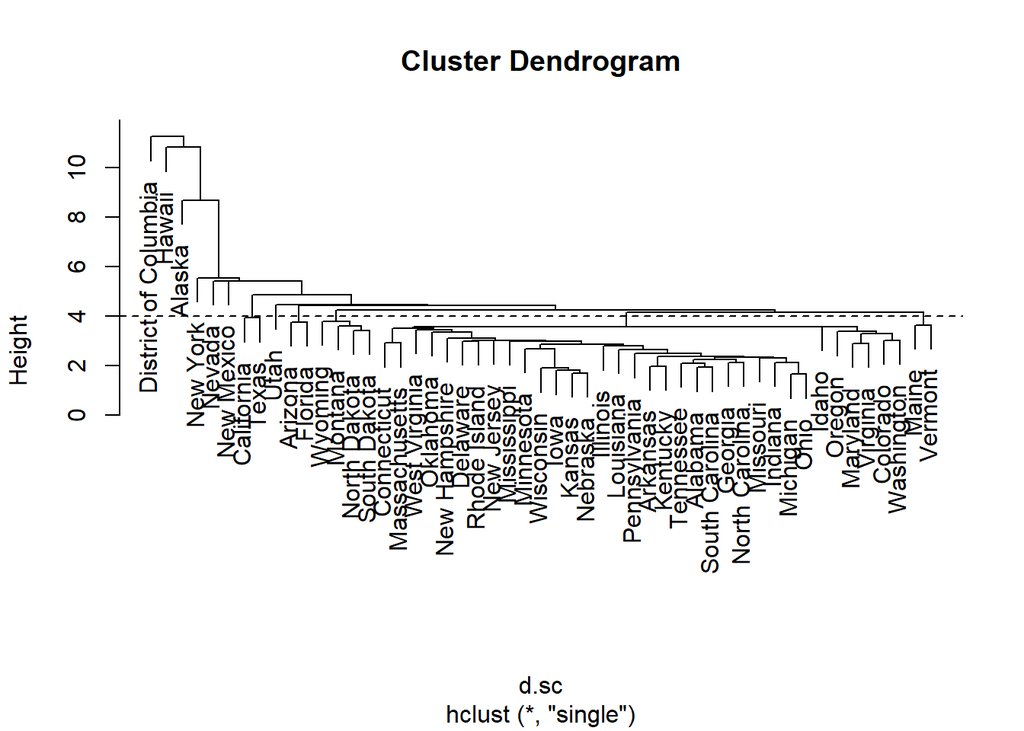

```r
hclus.sing <- hclust(d.sc, method = "single")
  plot(hclus.sing)
  abline(h = 4, lty = 2)
```

```r
  clus.sing <- as.character(cutree(hclus.sing, h = 4))
    table(clus.sing)
```

```
## clus.sing
##  1 10 11 12  2  3  4  5  6  7  8  9
## 34  1  1  1  1  2  2  1  1  2  4  1
```

A cut at a height of 4 gives us 12 clusters.

## (7) There should be two clusters with more than two observations in them. Verify that the minimum distance between any observations in these two (different) clusters is greater than our cut height. Explain why this must be the case.

```r
d.18 <- d.mat[which(clus.sing == "1"),
              which(clus.sing == "8")]

min(d.18)
```

```
## [1] 4.272684
```

Clusters 1 and 8 are the only two that had more than two observations in each. So we look at the minimum distance between any two observations in opposite clusters. The minimum distance is 4.27, which is greater than the cut height of 4. This must be the case. Otherwise, they would have been put in the same cluster.

## (8) There should be one cluster with four observations. Verify that for every observation in this cluster, there is at least one other observation in this cluster that’s within our cut height.

```r
# cut height h=4
d.88 <- d.mat[which(clus.sing == "8"),
              which(clus.sing == "8")]
d.88[1, ]
```

```
##      Montana North Dakota South Dakota      Wyoming
##     0.000000     4.923754     3.617437     5.013075
```

```r
d.88[2, ]
```

```
##      Montana North Dakota South Dakota      Wyoming
##     4.923754     0.000000     3.437954     3.799367
```

```r
d.88[3, ]
```

```
##      Montana North Dakota South Dakota      Wyoming
##     3.617437     3.437954     0.000000     5.195567
```

```r
d.88[4, ]
```

```
##      Montana North Dakota South Dakota      Wyoming
##     5.013075     3.799367     5.195567     0.000000
```

Cluster 8 is the only cluster with exactly four observations. Montana is within 4 units from South Dakota (3.617). North Dakota is within 4 units of South Dakota (3.44) and Wyoming (3.799). South Dakota is within 4 units of Montana (3.617) and North Dakota (3.44). Wyoming is within 4 units of North Dakota (3.799).

## (9) - (10) Now, run hierarchical clustering with complete linkage. Plot the dendrogram so that all of the state names are along the horizontal axis (as opposed to different heights). Draw a dashed horizontal line at a height of 8.5. How many clusters would we have if we make a cut at a height of 8.5?

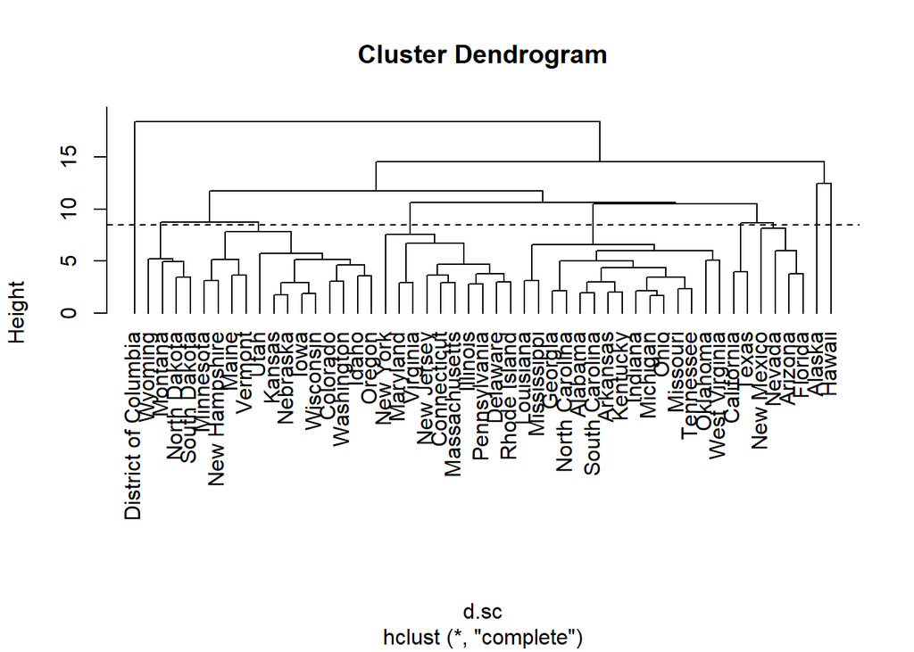

```r
hclus.comp <- hclust(d.sc, method = "complete")
  plot(hclus.comp, hang = -1)
  abline(h = 8.5, lty = 2)
```

```r
  clus.comp <- as.character(cutree(hclus.comp, h = 8.5))
  table(clus.comp)
```

```
## clus.comp
##  1  2  3  4  5  6  7  8  9
## 15  1  4  2 13 10  1  1  4
```

The `hang = -1` in the `plot( )` function forces the observation names (states here) to be all along the horizontal axis. Using complete linkage and a cut at a height of 8.5, we get 9 clusters.

## (11) There should be two clusters with four observations. Verify that the maximum distance between any observations in these opposing clusters is greater than the cut height

```r
d.39 <-  d.mat[which(clus.comp == "3"),
               which(clus.comp == "9")]

max(d.39)
```

```
## [1] 11.0127
```

Clusters 3 and 9 have four observations in each. The maximum distance between any observations in opposing clusters is greater than 8.5, which is the cut height.

## (12) Pick either one of the two clusters from the previous step. Verify that for every observation in this cluster, all the other observations in that cluster are within our cut height

```r
d.33 <- d.mat[which(clus.comp == "3"),
              which(clus.comp == "3")]
  d.33[1, ]
```

```
##    Arizona    Florida     Nevada New Mexico
##   0.000000   3.757536   5.431406   5.428032
```

```r
  d.33[2, ]
```

```
##    Arizona    Florida     Nevada New Mexico
##   3.757536   0.000000   6.009462   7.691910
```

```r
  d.33[3, ]
```

```
##    Arizona    Florida     Nevada New Mexico
##   5.431406   6.009462   0.000000   8.134072
```

```r
  d.33[4, ]
```

```
##    Arizona    Florida     Nevada New Mexico
##   5.428032   7.691910   8.134072   0.000000
```

```r
d.99 <- d.mat[which(clus.comp == "9"),
              which(clus.comp == "9")]
  d.99[1, ]
```

```
##      Montana North Dakota South Dakota      Wyoming
##     0.000000     4.923754     3.617437     5.013075
```

```r
  d.99[2, ]
```

```
##      Montana North Dakota South Dakota      Wyoming
##     4.923754     0.000000     3.437954     3.799367
```

```r
  d.99[3, ]
```

```
##      Montana North Dakota South Dakota      Wyoming
##     3.617437     3.437954     0.000000     5.195567
```

```r
  d.99[4, ]
```

```
##      Montana North Dakota South Dakota      Wyoming
##     5.013075     3.799367     5.195567     0.000000
```

Cluster 9 also had four observations. Again, we can see that all the observations within this cluster are within 8.5 units (the cut height) of each other.

## (13) Use code from the dendextend package to plot the dendrogram. Color the branches and labelsby their cluster assignments.

Color coordinate observations by cluster assignment using complete linkage and a cut height of 8.5.

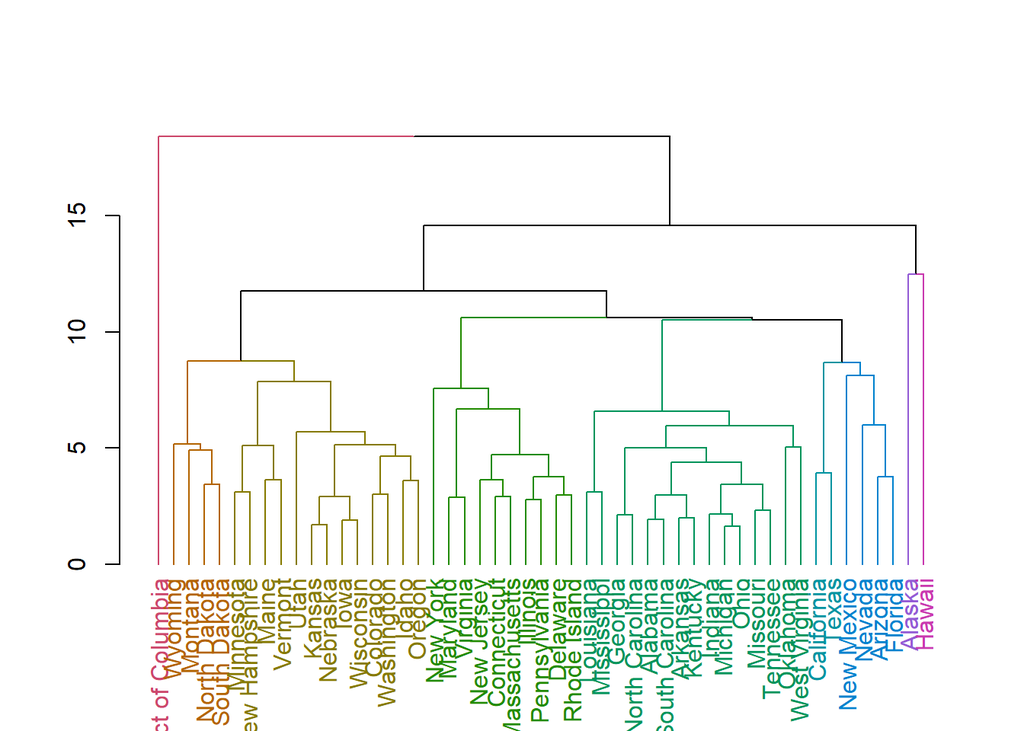

```r
library(dendextend)

dend <- as.dendrogram(hclus.comp)
dend <- color_labels(dend, h = 8.5)
dend <- color_branches(dend, h = 8.5)
plot(dend)
```